# Corrected Data

Brian

2022-08-23

# Disclaimer

*This work is very preliminary as I get back into the coding swing of things. Data wrangling and figure generation will be done via R, but the rest of the project will be done using good ol’ microsoft products. This is just an entry point into data crunching and should by no means be considered a final product.*

# Notes from SF 12/8

Find a station where there is an obvious change using Morrisey, run the time series with what I have, then do it with the Morrisey and compare the two in a figure. Find the equation of the lines, r^2, etc.

H1 is the Morrisey method, H2 is the Oiler.

Update your amounts of stations with a buffered layer in ArcGIS.

Rabbit Ears 709 (Morrisey), Dry Lake 457 (Oiler), Columbine 408 (Morrisey).

```r
SNOTEL_StudyArea <- read.csv("C:/Users/bsteen/OneDrive - Colostate/Documents/MS_Research/Research_via_campus/data_raw/SNOTEL_StudyArea.csv", header = TRUE)

snotel_709 <- SNOTEL_StudyArea %>%
  filter(site_id == "709")

# trying to determine what is an outlier vs an extreme, comparing to neighboring SNOTEL
snotel_457 <- SNOTEL_StudyArea %>%
  filter(site_id == "457")

# waiting for input. Columbine 408 is not in the area (part of the 16 stations inside the basin, likely needs to be included in the buffer.)

snotel_408 <- snotel_download(site_id = 408, path = tempdir('../data'), internal = TRUE)
```

Trying to figure out what anomalies are there. 98 Celsius seems hot. Checking against NRCS, these values are in Celsius.

# Data Cleaning

### Rabbit Ears 709

```r
head(snotel_709) # check the date, usually a character.
```

```
##   network state    site_name                   description      start
## 1    SNTL    CO rabbit ears  Harrison Creek (140500010402) 1985-10-01
## 2    SNTL    CO rabbit ears  Harrison Creek (140500010402) 1985-10-01
## 3    SNTL    CO rabbit ears  Harrison Creek (140500010402) 1985-10-01
## 4    SNTL    CO rabbit ears  Harrison Creek (140500010402) 1985-10-01
## 5    SNTL    CO rabbit ears  Harrison Creek (140500010402) 1985-10-01
## 6    SNTL    CO rabbit ears  Harrison Creek (140500010402) 1985-10-01
##          end latitude longitude elev county site_id       date
## 1 2022-08-23    40.37   -106.74 2868  Routt     709 1986-09-18
## 2 2022-08-23    40.37   -106.74 2868  Routt     709 1986-09-19
## 3 2022-08-23    40.37   -106.74 2868  Routt     709 1986-09-20
## 4 2022-08-23    40.37   -106.74 2868  Routt     709 1986-09-21
## 5 2022-08-23    40.37   -106.74 2868  Routt     709 1986-09-22
## 6 2022-08-23    40.37   -106.74 2868  Routt     709 1986-09-23
##   snow_water_equivalent precipitation_cumulative temperature_max
## 1                    NA                       NA           -51.3
## 2                     0                       NA              NA
## 3                     0                       NA            14.7
## 4                     0                       NA            11.3
## 5                     0                       NA            10.5
## 6                     3                       NA            10.4
##   temperature_min temperature_mean precipitation
## 1           -51.3            -51.3            NA
## 2              NA               NA            NA
## 3             6.4              9.8            NA
## 4             4.8              7.2            NA
## 5             0.9              5.4            NA
## 6             1.3              4.9            NA
```

```r
snotel_709$Date <- as.Date(snotel_709$date) #change date from character to date format, capitalize to work with Water year functon from NWIS.

snotel_709_clean <- snotel_709 %>% # filter for the timeframe
  filter(Date >= "1986-09-19" & Date <= "2021-09-30") %>%
  #filter(temperature_mean >= -30 & temperature_mean <= 20) %>% # removing outliers
  addWaterYear() %>%
  mutate(daymonth = format(as.Date(Date), "%d-%m")) %>%
  na.omit()

#adding water day using difftime (SUPER COOL. example from [this](https://stackoverflow.com/questions/48123049/create-day-index-based-on-water-year))

snotel_709_clean <- snotel_709_clean %>%
  group_by(waterYear)%>%
  mutate(waterDay = (as.integer(difftime(Date, ymd(paste0(waterYear - 1 ,'-09-30')), units = "days"))))
```

```r
snotel_709_clean <- snotel_709_clean %>%
  mutate(temp_diff = abs(temperature_min - temperature_max)) %>%
  filter(temperature_min <= 20)

# Still too many. Going to have to cull a lot of years.
```

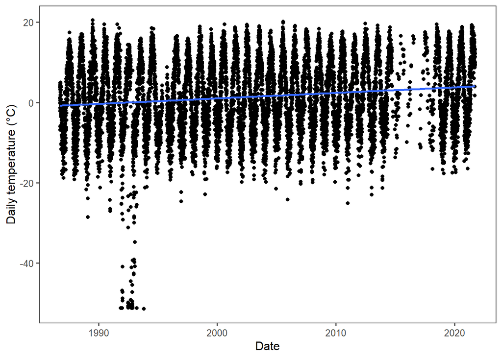

```r
ggplot(snotel_709_clean, aes(x = Date, y = temperature_mean)) +
  geom_point() + #lwd = 2) +
  theme_few() +
  geom_smooth(method = "lm", se=FALSE) +
  ylab('Daily temperature (°C)') +
  xlab('Date')
```

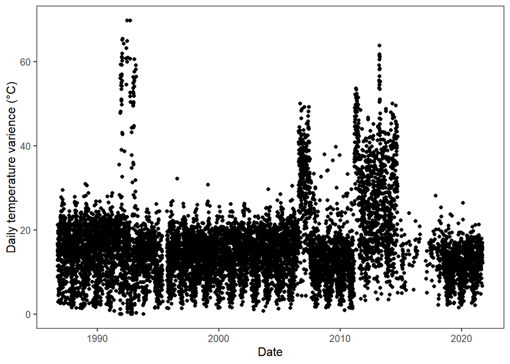

```r
ggplot(snotel_709_clean, aes(x = Date, y = temp_diff)) +
  geom_point() + #lwd = 2) +
  theme_few() +
  #geom_smooth(method = "lm", se=FALSE) +
  ylab('Daily temperature varience (°C)') +
  xlab('Date')
```

Need to figure out the outlier issue.

Per Steven’s advice: :If there are more than 15 missing days, then…remove that year”

```r
# filtering for temperature anomalies
snotel_709_cull_count <- snotel_709_clean %>%
  filter(temperature_min < -30) %>%
  count(waterYear)

snotel_709_cull_count
```

```
## # A tibble: 6 × 2
## # Groups:   waterYear [6]
##   waterYear     n
##       <dbl> <int>
## 1      1989     2
## 2      1991     2
## 3      1992    61
## 4      1993    74
## 5      1994     1
## 6      2007     2
```

```r
# filtering for too few observations in a year
snotel_709_cull_count_days <- snotel_709_clean %>%
  group_by(waterYear) %>%
  count(waterYear)

snotel_709_cull_count_days
```

```
## # A tibble: 35 × 2
## # Groups:   waterYear [35]
##    waterYear     n
##        <dbl> <int>
##  1      1987   359
##  2      1988   366
##  3      1989   364
##  4      1990   365
##  5      1991   365
##  6      1992   346
##  7      1993   344
##  8      1994   333
##  9      1995   169
## 10      1996   361
## # … with 25 more rows
```

```r
# For export for SF:

# write.csv(snotel_709_cull_count_days,"C:/Users/bsteen/OneDrive - Colostate/Documents/MS_Research/research_morrisey_method/data_clean/snotel_709_cull_count_days.csv", row.names = FALSE)
```

```r
snotel_709_clean_culled <- snotel_709_clean %>%
  filter(waterYear != "1992" & waterYear != "1993" & waterYear != "1995" & waterYear != "2014" & waterYear != "2015"& waterYear != "2016" & waterYear != "2017" & waterYear != "2018") %>%
  filter(temperature_mean > -49)
```

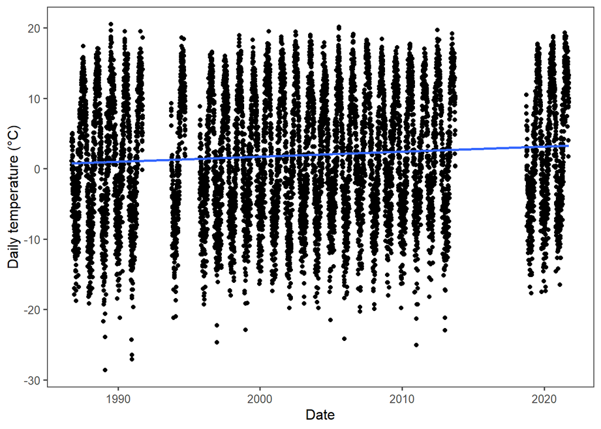

```r
ggplot(snotel_709_clean_culled, aes(x = Date, y = temperature_mean)) +
  geom_point() + #lwd = 2) +
  theme_few() +
  geom_smooth(method = "lm", se=FALSE) +
  ylab('Daily temperature (°C)') +
  xlab('Date')
```

Much better. Changing the minimum temperature within a range of -30 to -40°C did not affect which years were culled.

Due to the trials of the above cleaning, I tried some neighboring stations below:

### Dry Lake 457

```r
head(snotel_457) # check the date, usually a character.
```

```
##   network state site_name                                          description
## 1    SNTL    CO dry lake  City of Steamboat Springs-Yampa River (140500010409)
## 2    SNTL    CO dry lake  City of Steamboat Springs-Yampa River (140500010409)
## 3    SNTL    CO dry lake  City of Steamboat Springs-Yampa River (140500010409)
## 4    SNTL    CO dry lake  City of Steamboat Springs-Yampa River (140500010409)
## 5    SNTL    CO dry lake  City of Steamboat Springs-Yampa River (140500010409)
## 6    SNTL    CO dry lake  City of Steamboat Springs-Yampa River (140500010409)
##        start        end latitude longitude elev county site_id       date
## 1 1979-10-01 2022-08-23    40.53   -106.78 2521  Routt     457 1980-10-01
## 2 1979-10-01 2022-08-23    40.53   -106.78 2521  Routt     457 1980-10-02
## 3 1979-10-01 2022-08-23    40.53   -106.78 2521  Routt     457 1980-10-03
## 4 1979-10-01 2022-08-23    40.53   -106.78 2521  Routt     457 1980-10-04
## 5 1979-10-01 2022-08-23    40.53   -106.78 2521  Routt     457 1980-10-05
## 6 1979-10-01 2022-08-23    40.53   -106.78 2521  Routt     457 1980-10-06
##   snow_water_equivalent precipitation_cumulative temperature_max
## 1                     0                        0              NA
## 2                     0                        0              NA
## 3                     0                        0              NA
## 4                     0                        0              NA
## 5                     0                        0              NA
## 6                     0                        0              NA
##   temperature_min temperature_mean precipitation
## 1              NA               NA             0
## 2              NA               NA             0
## 3              NA               NA             0
## 4              NA               NA             0
## 5              NA               NA             0
## 6              NA               NA             0
```

```r
snotel_457$Date <- as.Date(snotel_457$date) #change date from character to date format, capitalize to work with Water year functon from NWIS.

snotel_457_clean <- snotel_457 %>% # filter for the timeframe
  filter(Date >= "1978-09-19" & Date <= "2021-09-30") %>%
  #filter(temperature_mean >= -30 & temperature_mean <= 20) %>% # removing outliers
  addWaterYear() %>%
  mutate(daymonth = format(as.Date(Date), "%d-%m")) %>%
  na.omit()

#adding water day using difftime (SUPER COOL. example from [this](https://stackoverflow.com/questions/48123049/create-day-index-based-on-water-year))

snotel_457_clean <- snotel_457_clean %>%
  group_by(waterYear)%>%
  mutate(waterDay = (as.integer(difftime(Date, ymd(paste0(waterYear - 1 ,'-09-30')), units = "days")))) %>%
  filter(temperature_mean >= -40) %>%   # trying to remove outliers
  mutate(temp_diff = abs(temperature_min - temperature_max))
```

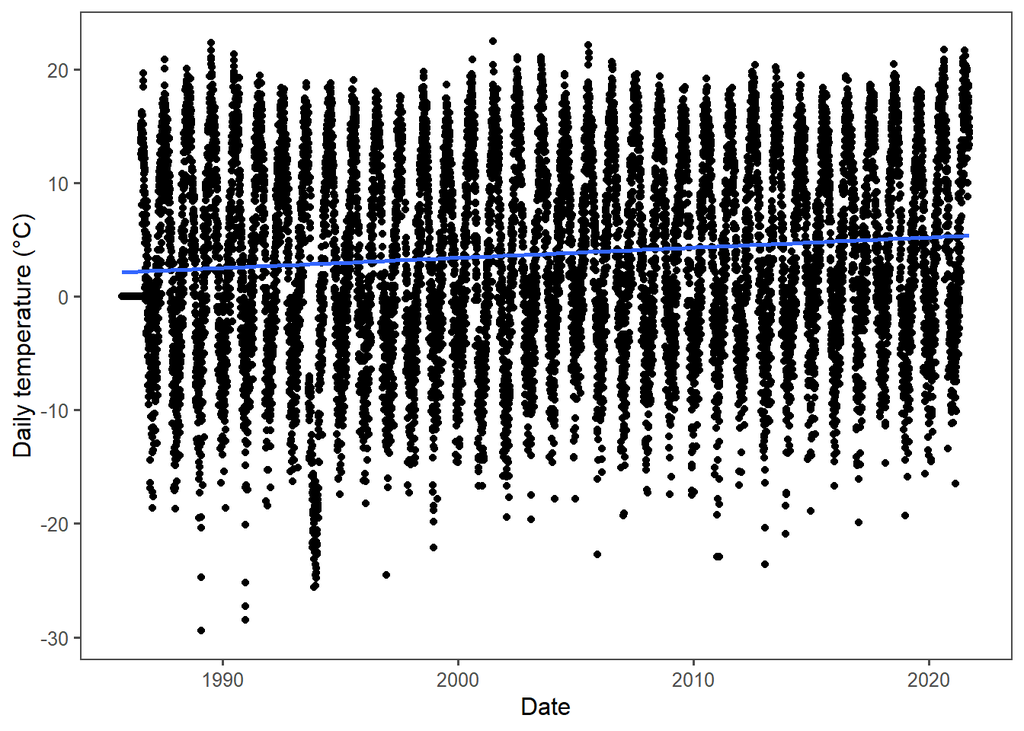

```r
ggplot(snotel_457_clean, aes(x = Date, y = temperature_mean)) +
  geom_point() + #lwd = 2) +
  theme_few() +
  geom_smooth(method = "lm", se=FALSE) +
  ylab('Daily temperature (°C)') +
  xlab('Date')
```

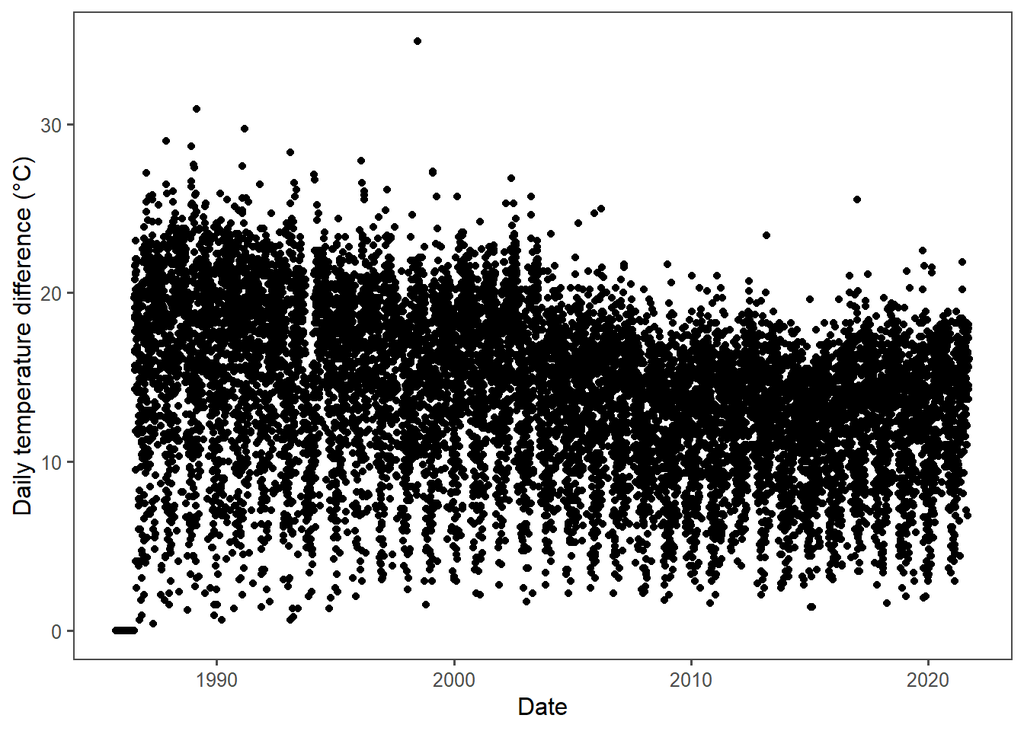

```r
ggplot(snotel_457_clean, aes(x = Date, y = temp_diff)) +
  geom_point() + #lwd = 2) +
  theme_few() +
  #geom_smooth(method = "lm", se=FALSE) +
  ylab('Daily temperature difference (°C)') +
  xlab('Date')
```

### Columbine 408

```r
head(snotel_408) # check the date, usually a character.
```

```
##   network state  site_name                        description      start
## 1    SNTL    CO columbine  Upper Grizzly Creek (101800010102) 1978-10-01
## 2    SNTL    CO columbine  Upper Grizzly Creek (101800010102) 1978-10-01
## 3    SNTL    CO columbine  Upper Grizzly Creek (101800010102) 1978-10-01
## 4    SNTL    CO columbine  Upper Grizzly Creek (101800010102) 1978-10-01
## 5    SNTL    CO columbine  Upper Grizzly Creek (101800010102) 1978-10-01
## 6    SNTL    CO columbine  Upper Grizzly Creek (101800010102) 1978-10-01
##          end latitude longitude elev  county site_id       date
## 1 2022-08-26     40.4    -106.6 2794 Jackson     408 1978-10-01
## 2 2022-08-26     40.4    -106.6 2794 Jackson     408 1978-10-02
## 3 2022-08-26     40.4    -106.6 2794 Jackson     408 1978-10-03
## 4 2022-08-26     40.4    -106.6 2794 Jackson     408 1978-10-04
## 5 2022-08-26     40.4    -106.6 2794 Jackson     408 1978-10-05
## 6 2022-08-26     40.4    -106.6 2794 Jackson     408 1978-10-06
##   snow_water_equivalent precipitation_cumulative temperature_max
## 1                    NA                       NA               0
## 2                    NA                       NA               0
## 3                    NA                       NA               0
## 4                    NA                       NA               0
## 5                    NA                       NA               0
## 6                    NA                       NA               0
##   temperature_min temperature_mean precipitation
## 1               0                0            NA
## 2               0                0            NA
## 3               0                0            NA
## 4               0                0            NA
## 5               0                0            NA
## 6               0                0            NA
```

```r
snotel_408$Date <- as.Date(snotel_408$date) #change date from character to date format, capitalize to work with Water year functon from NWIS.

snotel_408_clean <- snotel_408 %>% # filter for the timeframe
  filter(Date >= "1982-10-16" & Date <= "2021-09-30") %>%
  #filter(temperature_mean >= -30 & temperature_mean <= 20) %>% # removing outliers
  addWaterYear() %>%
  mutate(daymonth = format(as.Date(Date), "%d-%m")) %>%
  na.omit()

#adding water day using difftime (SUPER COOL. example from [this](https://stackoverflow.com/questions/48123049/create-day-index-based-on-water-year))

snotel_408_clean <- snotel_408_clean %>%
  group_by(waterYear)%>%
  mutate(waterDay = (as.integer(difftime(Date, ymd(paste0(waterYear - 1 ,'-09-30')), units = "days")))) %>%
  #filter(temperature_mean >= -40) %>%   # trying to remove outliers
  mutate(temp_diff = abs(temperature_min - temperature_max))
```

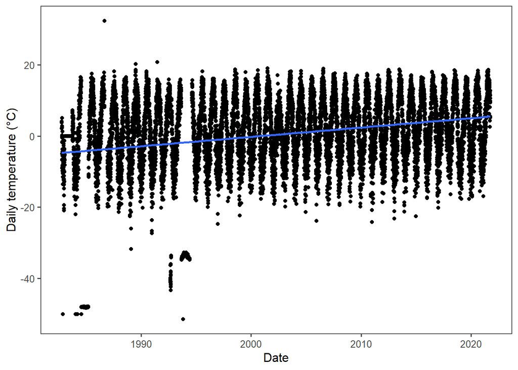

```r
ggplot(snotel_408_clean, aes(x = Date, y = temperature_mean)) +
  geom_point() + #lwd = 2) +
  theme_few() +
  geom_smooth(method = "lm", se=FALSE) +
  ylab('Daily temperature (°C)') +
  xlab('Date')
```

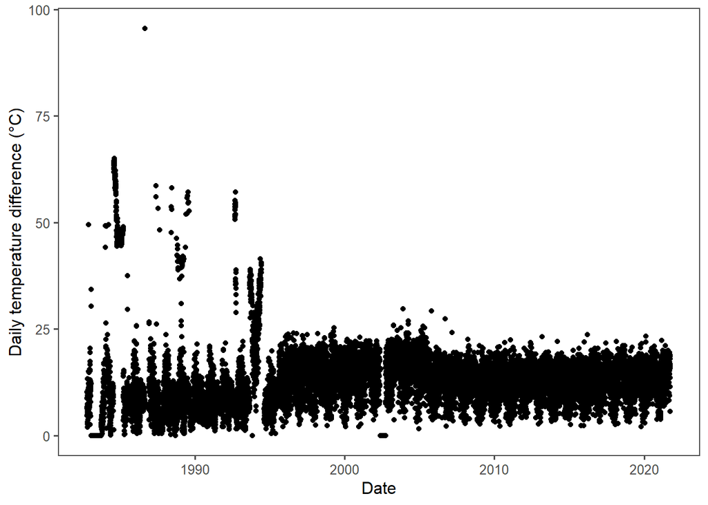

```r
ggplot(snotel_408_clean, aes(x = Date, y = temp_diff)) +
  geom_point() + #lwd = 2) +
  theme_few() +
  #geom_smooth(method = "lm", se=FALSE) +
  ylab('Daily temperature difference (°C)') +
  xlab('Date')
```

```r
snotel_408_cull <- snotel_408_clean %>%
  filter(temperature_min < -30)

snotel_408_cull
```

```
## # A tibble: 577 × 23
## # Groups:   waterYear [10]
##    network state site_name   descr…¹ start      end        latit…² longi…³  elev
##    <chr>   <chr> <chr>       <chr>   <date>     <date>       <dbl>   <dbl> <dbl>
##  1 SNTL    CO    "columbine… Upper … 1978-10-01 2022-08-26    40.4   -107.  2794
##  2 SNTL    CO    "columbine… Upper … 1978-10-01 2022-08-26    40.4   -107.  2794
##  3 SNTL    CO    "columbine… Upper … 1978-10-01 2022-08-26    40.4   -107.  2794
##  4 SNTL    CO    "columbine… Upper … 1978-10-01 2022-08-26    40.4   -107.  2794
##  5 SNTL    CO    "columbine… Upper … 1978-10-01 2022-08-26    40.4   -107.  2794
##  6 SNTL    CO    "columbine… Upper … 1978-10-01 2022-08-26    40.4   -107.  2794
##  7 SNTL    CO    "columbine… Upper … 1978-10-01 2022-08-26    40.4   -107.  2794
##  8 SNTL    CO    "columbine… Upper … 1978-10-01 2022-08-26    40.4   -107.  2794
##  9 SNTL    CO    "columbine… Upper … 1978-10-01 2022-08-26    40.4   -107.  2794
## 10 SNTL    CO    "columbine… Upper … 1978-10-01 2022-08-26    40.4   -107.  2794
## # … with 567 more rows, 14 more variables: county <chr>, site_id <dbl>,
## #   date <chr>, snow_water_equivalent <int>, precipitation_cumulative <int>,
## #   temperature_max <dbl>, temperature_min <dbl>, temperature_mean <dbl>,
## #   precipitation <int>, Date <date>, waterYear <dbl>, daymonth <chr>,
## #   waterDay <int>, temp_diff <dbl>, and abbreviated variable names
## #   ¹description, ²latitude, ³longitude
```

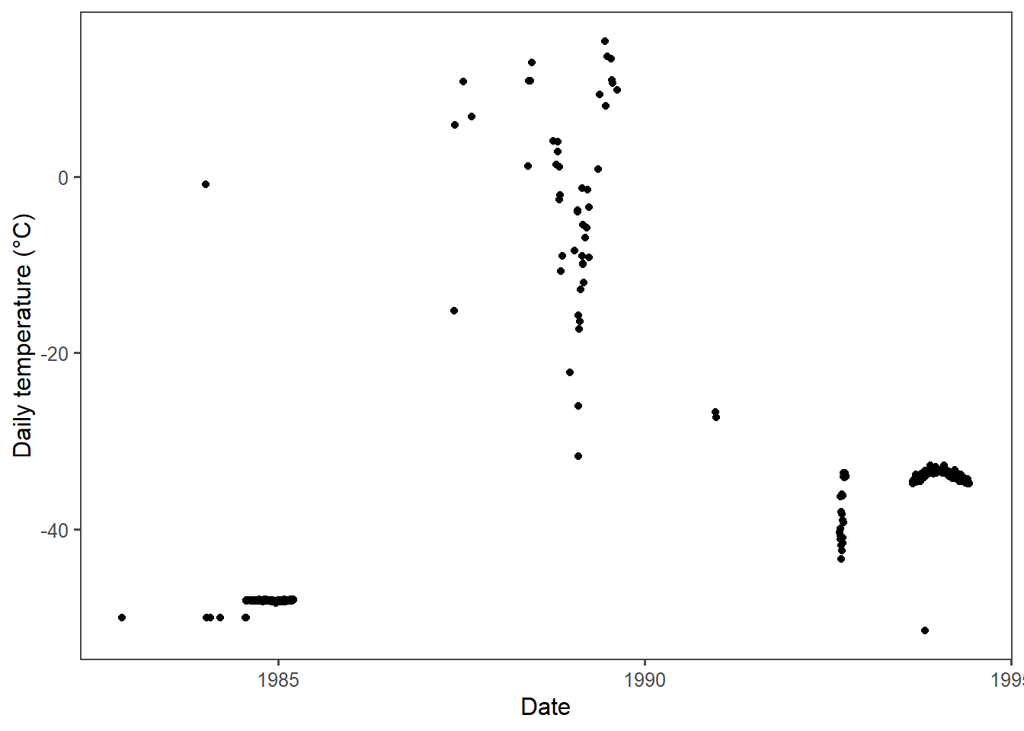

```r
ggplot(snotel_408_cull, aes(x = Date, y = temperature_mean)) +
  geom_point() + #lwd = 2) +
  theme_few() +
  #geom_smooth(method = "lm", se=FALSE) +
  ylab('Daily temperature (°C)') +
  xlab('Date')
```

```r
temp_408_xts <- xts(snotel_408_cull$temperature_min, order.by = snotel_408_cull$Date)

dygraph(temp_408_xts) %>%
  dyAxis("y", label = "Daily temperature (°C)")
```

[interactive chart not shown]

Per Steven’s advice: :If there are more than 15 missing days, then…remove that year”

```r
snotel_408_cull_count <- snotel_408_clean %>%
  filter(temperature_min < -30) %>%
  count(waterYear)

snotel_408_cull_count
```

```
## # A tibble: 10 × 2
## # Groups:   waterYear [10]
##    waterYear     n
##        <dbl> <int>
##  1      1983     1
##  2      1984    73
##  3      1985   166
##  4      1987     4
##  5      1988     4
##  6      1989    39
##  7      1991     2
##  8      1992    30
##  9      1993    31
## 10      1994   227
```

```r
# 1983 will be excluded due to a lack of data (sensors reading 0)

snotel_408_cull_count_days <- snotel_408_clean %>%
  group_by(waterYear) %>%
  count(waterYear)

snotel_408_cull_count_days
```

```
## # A tibble: 39 × 2
## # Groups:   waterYear [39]
##    waterYear     n
##        <dbl> <int>
##  1      1983   305
##  2      1984   306
##  3      1985   361
##  4      1986   336
##  5      1987   298
##  6      1988   365
##  7      1989   364
##  8      1990   365
##  9      1991   359
## 10      1992   366
## # … with 29 more rows
```

1983, 1987, 1994 all have too few observations. (Others may be too low as well. No limit yet.)

```r
snotel_408_clean_culled <- snotel_408_clean %>%
  filter(waterYear != "1983" & waterYear != "1984" & waterYear != "1985" & waterYear != "1987" & waterYear != "1989" & waterYear != "1992" & waterYear != "1993" & waterYear != "1994") %>%
  filter(temperature_mean < 25) %>%
  filter(temperature_mean > -49)
```

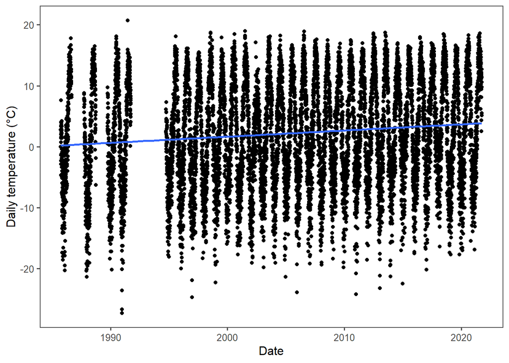

```r
ggplot(snotel_408_clean_culled, aes(x = Date, y = temperature_mean)) +
  geom_point() + #lwd = 2) +
  theme_few() +
  geom_smooth(method = "lm", se=FALSE) +
  ylab('Daily temperature (°C)') +
  xlab('Date')
```

# Morrisey Method

The Morrisey Method is taken from [Ma, Fassnacht and Kampf.](https://agupubs.onlinelibrary.wiley.com/doi/epdf/10.1029/2019WR025921).

## Rabbit Ears 709 (adj)

8/7/2006 installed ext range sensor

```r
snotel_709_adjusted <- snotel_709_clean_culled %>%
  mutate(temp_ad = if_else(Date < "2006-8-7", ((5.3*10^(-7))*(temperature_mean^(4))+(3.72*10^(-5))*(temperature_mean^(3))-(2.16*10^(-3))*(temperature_mean^(2))-(7.32*10^(-2))*(temperature_mean)+1.37)+temperature_mean, temperature_mean))

#Checked with SF, helpful. Looks good.

# For export:

# RE709_SF_v2 <- snotel_709_adjusted %>%
#   select(Date, waterYear, temperature_mean, temp_ad)
#
# write.csv(RE709_SF_v2,"C:/Users/bsteen/OneDrive - Colostate/Documents/MS_Research/research_morrisey_method/data_clean/RE709_SF_v2.csv", row.names = FALSE)
```

### Non-corrected

#### 709 Detrended

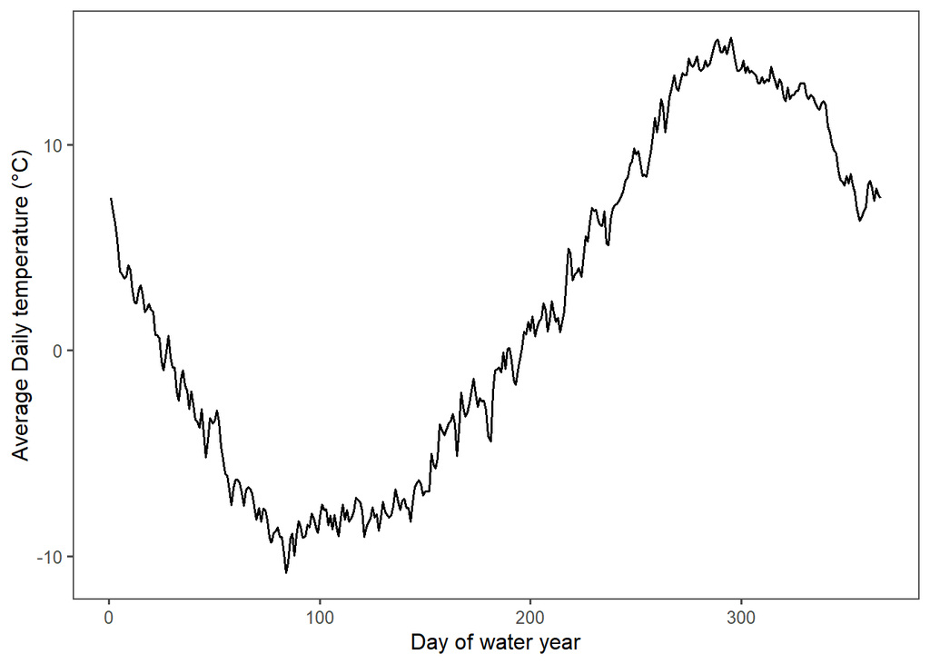

```r
#using the clean culled df:

#average water year temperature

yearly_wy_aver_709 <- snotel_709_adjusted %>%
  group_by(waterYear) %>%
  mutate(aver_ann_temp = mean(temperature_mean))

#Average temperature by day for all water years:

daily_wy_aver_709 <- yearly_wy_aver_709 %>%
  group_by(daymonth) %>%
  mutate(aver_day_temp = mean(aver_ann_temp))

#average mean temperature by day for the period of record:

daily_wy_aver_709 <- daily_wy_aver_709 %>%
  group_by(daymonth) %>%
  mutate(all_ave_temp = mean(daily_wy_aver_709$aver_day_temp))

# try to show all years as means.
daily_wy_aver2_709 <-daily_wy_aver_709 %>%
  group_by(waterDay) %>%
  mutate(date_temp = mean(temperature_mean))


daily_wy_aver2_709$date_temp <- signif(daily_wy_aver2_709$date_temp,3) #reduce the sig figs


ggplot(daily_wy_aver2_709, aes(x = waterDay, y = date_temp))+
  geom_line(size= 0.7) +
  theme_few() +
  ylab('Average Daily temperature (°C)') +
  xlab('Day of water year')
```

#### 709 SD

```r
standard_dev_709 <- daily_wy_aver_709 %>%
  group_by(waterYear) %>%
  #filter(waterYear >= 1987 & waterYear <= 2021) %>%
  mutate(residual = (all_ave_temp-aver_ann_temp)+temperature_mean-aver_day_temp) %>%
  mutate(deviation = abs(residual-lag(residual)))

standard_dev_all_709 <- standard_dev_709 %>%
  group_by(waterYear) %>%
  mutate(nmbr = n())

standard_dev_all_709 <- standard_dev_all_709 %>%
  group_by(waterYear) %>%
  mutate(resid_mean = mean(residual)) %>%
  mutate(sd_1 = residual-resid_mean) %>%
  mutate(sd_2 = (((sum((sd_1)^2))/((nmbr-1))))^(0.5)) %>%
  distinct(sd_2, .keep_all = TRUE) %>%
   select(waterYear, sd_2)

standard_dev_all_709 %>%
  kable(.,'html') %>%
  kable_styling() %>%
  scroll_box(width='250px',height='500px')
```

| waterYear | sd_2 |
| --- | --- |
| 1987 | 8.594074 |
| 1988 | 9.659300 |
| 1989 | 9.448116 |
| 1990 | 9.028531 |
| 1991 | 9.414023 |
| 1994 | 9.591400 |
| 1996 | 8.845000 |
| 1997 | 8.863819 |
| 1998 | 9.078563 |
| 1999 | 8.308555 |
| 2000 | 8.747166 |
| 2001 | 9.426411 |
| 2002 | 9.842980 |
| 2003 | 9.010964 |
| 2004 | 8.577725 |
| 2005 | 8.454854 |
| 2006 | 9.191695 |
| 2007 | 9.308137 |
| 2008 | 9.038146 |
| 2009 | 8.122621 |
| 2010 | 8.958232 |
| 2011 | 8.676651 |
| 2012 | 8.713704 |
| 2013 | 9.312223 |
| 2019 | 8.738926 |
| 2020 | 9.195773 |
| 2021 | 9.080656 |

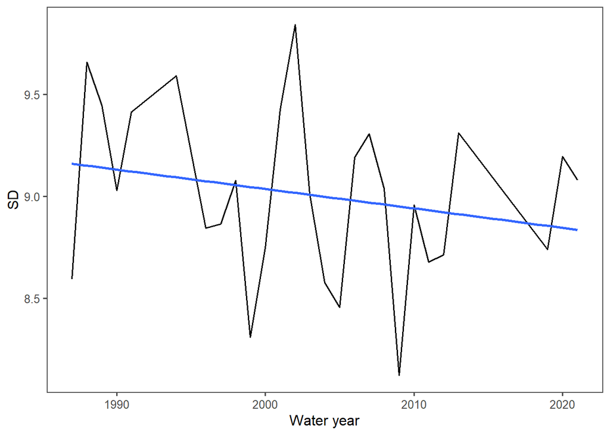

```r
ggplot(standard_dev_all_709, aes(x = waterYear, y = sd_2))+
  geom_line(size= 0.7) +
  theme_few() +
  geom_smooth(method = "lm", se=FALSE) +
  ylab('SD') +
  xlab('Water year')
```

*Non-corrected standard deviation of Rabbit Ears SNOTEL average temperatures for water years 1987-2021*

#### MK & SS for 709 (non-corrected)

```r
sd_mk_709 <- mk.test(standard_dev_all_709$sd_2)
print(sd_mk_709)
```

```
##
##  Mann-Kendall trend test
##
## data:  standard_dev_all_709$sd_2
## z = -1.0007, n = 27, p-value = 0.317
## alternative hypothesis: true S is not equal to 0
## sample estimates:
##            S         varS          tau
##  -49.0000000 2301.0000000   -0.1396011
```

```r
sd_sens_709 <- sens.slope(standard_dev_all_709$sd_2)
print(sd_sens_709)
```

```
##
##  Sen's slope
##
## data:  standard_dev_all_709$sd_2
## z = -1.0007, n = 27, p-value = 0.317
## alternative hypothesis: true z is not equal to 0
## 95 percent confidence interval:
##  -0.03890661  0.01418457
## sample estimates:
## Sen's slope
##  -0.0133691
```

### Corrected

#### 709 Detrended (corrected)

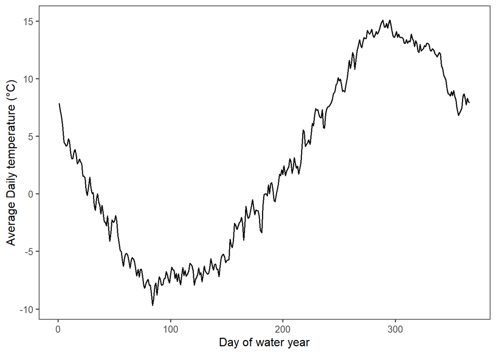

```r
#using the clean culled df:

#average water year temperature

yearly_wy_aver_709_ad <- snotel_709_adjusted %>%
  group_by(waterYear) %>%
  mutate(aver_ann_temp_ad = mean(temp_ad))

#Average temperature by day for all water years:

daily_wy_aver_709_ad <- yearly_wy_aver_709_ad %>%
  group_by(daymonth) %>%
  mutate(aver_day_temp_ad = mean(aver_ann_temp_ad))

#average mean temperature by day for the period of record:

daily_wy_aver_709_ad <- daily_wy_aver_709_ad %>%
  group_by(daymonth) %>%
  mutate(all_ave_temp_ad = mean(daily_wy_aver_709_ad$aver_day_temp_ad))

# try to show all years as means.
daily_wy_aver2_709_ad <-daily_wy_aver_709_ad %>%
  group_by(waterDay) %>%
  mutate(date_temp_ad = mean(temp_ad))


daily_wy_aver2_709_ad$date_temp_ad <- signif(daily_wy_aver2_709_ad$date_temp_ad,3) #reduce the sig figs


ggplot(daily_wy_aver2_709_ad, aes(x = waterDay, y = date_temp_ad))+
  geom_line(size= 0.7) +
  theme_few() +
  ylab('Average Daily temperature (°C)') +
  xlab('Day of water year')
```

#### 709 SS (corrected)

```r
standard_dev_709_ad <- daily_wy_aver_709_ad %>%
  group_by(waterYear) %>%
  #filter(waterYear >= 1987 & waterYear <= 2021) %>%
  mutate(residual = (all_ave_temp_ad-aver_ann_temp_ad)+temp_ad-aver_day_temp_ad) %>%
  mutate(deviation = abs(residual-lag(residual)))

standard_dev_all_709_ad <- standard_dev_709_ad %>%
  group_by(waterYear) %>%
  mutate(nmbr = n())

standard_dev_all_709_ad <- standard_dev_all_709_ad %>%
  group_by(waterYear) %>%
  mutate(resid_mean = mean(residual)) %>%
  mutate(sd_1 = residual-resid_mean) %>%
  mutate(sd_2 = (((sum((sd_1)^2))/((nmbr-1))))^(0.5)) %>%
  distinct(sd_2, .keep_all = TRUE) %>%
   select(waterYear, sd_2)

standard_dev_all_709_ad %>%
  kable(.,'html') %>%
  kable_styling() %>%
  scroll_box(width='250px',height='500px')
```

| waterYear | sd_2 |
| --- | --- |
| 1987 | 7.983600 |
| 1988 | 8.995760 |
| 1989 | 8.824651 |
| 1990 | 8.375708 |
| 1991 | 8.783350 |
| 1994 | 8.897021 |
| 1996 | 8.208259 |
| 1997 | 8.250915 |
| 1998 | 8.409107 |
| 1999 | 7.722575 |
| 2000 | 8.068674 |
| 2001 | 8.723305 |
| 2002 | 9.138417 |
| 2003 | 8.317890 |
| 2004 | 7.976456 |
| 2005 | 7.814929 |
| 2006 | 8.522465 |
| 2007 | 9.303686 |
| 2008 | 9.035674 |
| 2009 | 8.119986 |
| 2010 | 8.953867 |
| 2011 | 8.676282 |
| 2012 | 8.711020 |
| 2013 | 9.309707 |
| 2019 | 8.735557 |
| 2020 | 9.191321 |
| 2021 | 9.076850 |

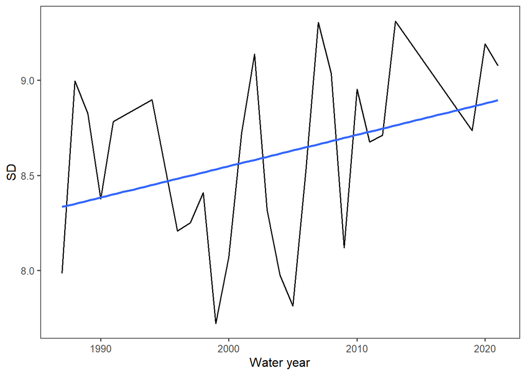

```r
ggplot(standard_dev_all_709_ad, aes(x = waterYear, y = sd_2))+
  geom_line(size= 0.7) +
  theme_few() +
  geom_smooth(method = "lm", se=FALSE) +
  ylab('SD') +
  xlab('Water year')
```

*Morrisey-corrected standard deviation of Rabbit Ears SNOTEL average temperatures for water years 1987-2021*

#### MK & SS 709 (corrected)

```r
sd_mk_709_ad <- mk.test(standard_dev_all_709_ad$sd_2)
print(sd_mk_709_ad)
```

```
##
##  Mann-Kendall trend test
##
## data:  standard_dev_all_709_ad$sd_2
## z = 1.6678, n = 27, p-value = 0.09536
## alternative hypothesis: true S is not equal to 0
## sample estimates:
##            S         varS          tau
##   81.0000000 2301.0000000    0.2307692
```

```r
sd_sens_709_ad <- sens.slope(standard_dev_all_709_ad$sd_2)
print(sd_sens_709_ad)
```

```
##
##  Sen's slope
##
## data:  standard_dev_all_709_ad$sd_2
## z = 1.6678, n = 27, p-value = 0.09536
## alternative hypothesis: true z is not equal to 0
## 95 percent confidence interval:
##  -0.004702366  0.044383379
## sample estimates:
## Sen's slope
##  0.02156524
```

## Notes from SF 25/8

We (you) could interpolate missing data from one station to another or at least use one station to determine if the data at a second station is not correct. [This paper may be useful.](https://doi.org/10.3850/IAHR-39WC2521716X20221604)

## Columbine 408 (adj)

7/22/2005 upgraded; installed ext range temp sensor

```r
snotel_408_adjusted <- snotel_408_clean_culled %>%
  mutate(temp_ad = if_else(Date < "2005-7-22", ((5.3*10^(-7))*(temperature_mean^(4))+(3.72*10^(-5))*(temperature_mean^(3))-(2.16*10^(-3))*(temperature_mean^(2))-(7.32*10^(-2))*(temperature_mean)+1.37)+temperature_mean, temperature_mean))

#Checked with SF, helpful. Looks good.

# For export:

# RE709_SF_v2 <- snotel_709_adjusted %>%
#   select(Date, waterYear, temperature_mean, temp_ad)
#
# write.csv(RE709_SF_v2,"C:/Users/bsteen/OneDrive - Colostate/Documents/MS_Research/research_morrisey_method/data_clean/RE709_SF_v2.csv", row.names = FALSE)
```

### Non-corrected

#### 408 Detrended

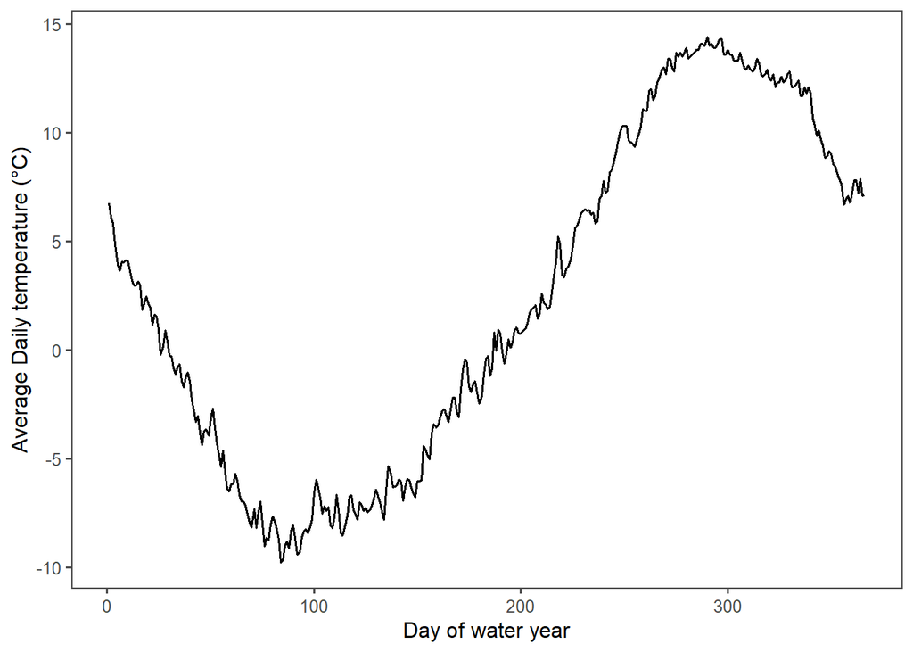

```r
#using the clean culled df:

#average water year temperature

yearly_wy_aver_408 <- snotel_408_adjusted %>%
  group_by(waterYear) %>%
  mutate(aver_ann_temp = mean(temperature_mean))

#Average temperature by day for all water years:

daily_wy_aver_408 <- yearly_wy_aver_408 %>%
  group_by(daymonth) %>%
  mutate(aver_day_temp = mean(aver_ann_temp))

#average mean temperature by day for the period of record:

daily_wy_aver_408 <- daily_wy_aver_408 %>%
  group_by(daymonth) %>%
  mutate(all_ave_temp = mean(daily_wy_aver_408$aver_day_temp))

# try to show all years as means.
daily_wy_aver2_408 <-daily_wy_aver_408 %>%
  group_by(waterDay) %>%
  mutate(date_temp = mean(temperature_mean))


daily_wy_aver2_408$date_temp <- signif(daily_wy_aver2_408$date_temp,3) #reduce the sig figs


ggplot(daily_wy_aver2_408, aes(x = waterDay, y = date_temp))+
  geom_line(size= 0.7) +
  theme_few() +
  ylab('Average Daily temperature (°C)') +
  xlab('Day of water year')
```

#### 408 SD

```r
standard_dev_408 <- daily_wy_aver_408 %>%
  group_by(waterYear) %>%
  #filter(waterYear >= 1987 & waterYear <= 2021) %>%
  mutate(residual = (all_ave_temp-aver_ann_temp)+temperature_mean-aver_day_temp) %>%
  mutate(deviation = abs(residual-lag(residual)))

standard_dev_all_408 <- standard_dev_408 %>%
  group_by(waterYear) %>%
  mutate(nmbr = n())

standard_dev_all_408 <- standard_dev_all_408 %>%
  group_by(waterYear) %>%
  mutate(resid_mean = mean(residual)) %>%
  mutate(sd_1 = residual-resid_mean) %>%
  mutate(sd_2 = (((sum((sd_1)^2))/((nmbr-1))))^(0.5)) %>%
  distinct(sd_2, .keep_all = TRUE) %>%
   select(waterYear, sd_2)

standard_dev_all_408 %>%
  kable(.,'html') %>%
  kable_styling() %>%
  scroll_box(width='250px',height='500px')
```

| waterYear | sd_2 |
| --- | --- |
| 1986 | 8.449287 |
| 1988 | 9.907454 |
| 1990 | 8.840467 |
| 1991 | 9.136876 |
| 1995 | 8.384584 |
| 1996 | 8.804118 |
| 1997 | 8.863108 |
| 1998 | 9.069632 |
| 1999 | 8.227666 |
| 2000 | 8.581424 |
| 2001 | 9.375225 |
| 2002 | 7.614865 |
| 2003 | 8.842344 |
| 2004 | 8.492769 |
| 2005 | 8.131061 |
| 2006 | 8.729962 |
| 2007 | 8.835574 |
| 2008 | 8.884652 |
| 2009 | 7.921775 |
| 2010 | 8.734587 |
| 2011 | 8.450977 |
| 2012 | 8.698206 |
| 2013 | 9.105660 |
| 2014 | 8.263712 |
| 2015 | 7.865772 |
| 2016 | 8.488801 |
| 2017 | 8.234585 |
| 2018 | 8.135374 |
| 2019 | 8.639468 |
| 2020 | 9.023276 |
| 2021 | 8.898687 |

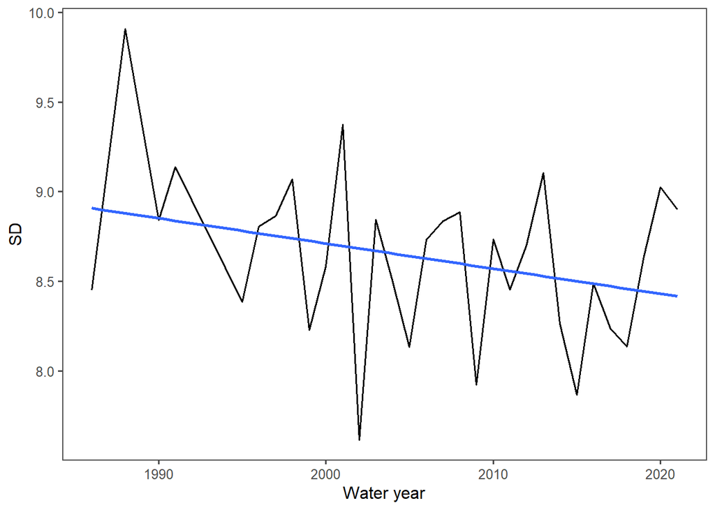

```r
ggplot(standard_dev_all_408, aes(x = waterYear, y = sd_2))+
  geom_line(size= 0.7) +
  theme_few() +
  geom_smooth(method = "lm", se=FALSE) +
  ylab('SD') +
  xlab('Water year')
```

#### MK & SD 408 (non-corrected)

```r
sd_mk_408 <- mk.test(standard_dev_all_408$sd_2)
print(sd_mk_408)
```

```
##
##  Mann-Kendall trend test
##
## data:  standard_dev_all_408$sd_2
## z = -1.1897, n = 31, p-value = 0.2341
## alternative hypothesis: true S is not equal to 0
## sample estimates:
##            S         varS          tau
##  -71.0000000 3461.6666667   -0.1526882
```

```r
sd_sens_408 <- sens.slope(standard_dev_all_408$sd_2)
print(sd_sens_408)
```

```
##
##  Sen's slope
##
## data:  standard_dev_all_408$sd_2
## z = -1.1897, n = 31, p-value = 0.2341
## alternative hypothesis: true z is not equal to 0
## 95 percent confidence interval:
##  -0.030397493  0.005660401
## sample estimates:
## Sen's slope
## -0.01162641
```

### Corrected

#### 408 Detrended (corrected)

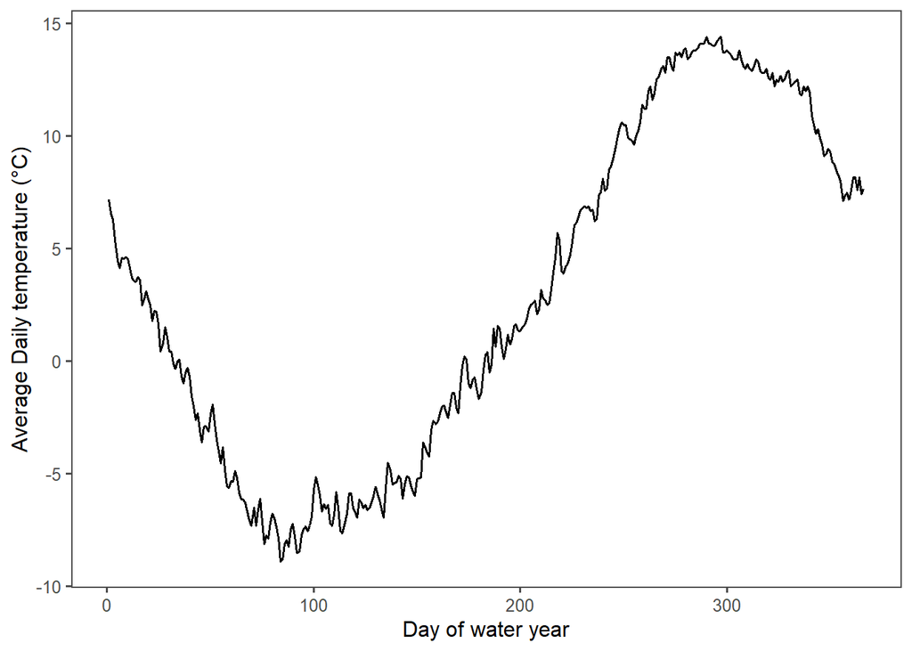

```r
#using the clean culled df:

#average water year temperature

yearly_wy_aver_408_ad <- snotel_408_adjusted %>%
  group_by(waterYear) %>%
  mutate(aver_ann_temp_ad = mean(temp_ad))

#Average temperature by day for all water years:

daily_wy_aver_408_ad <- yearly_wy_aver_408_ad %>%
  group_by(daymonth) %>%
  mutate(aver_day_temp_ad = mean(aver_ann_temp_ad))

#average mean temperature by day for the period of record:

daily_wy_aver_408_ad <- daily_wy_aver_408_ad %>%
  group_by(daymonth) %>%
  mutate(all_ave_temp_ad = mean(daily_wy_aver_408_ad$aver_day_temp_ad))

# try to show all years as means.
daily_wy_aver2_408_ad <-daily_wy_aver_408_ad %>%
  group_by(waterDay) %>%
  mutate(date_temp_ad = mean(temp_ad))


daily_wy_aver2_408_ad$date_temp_ad <- signif(daily_wy_aver2_408_ad$date_temp_ad,3) #reduce the sig figs


ggplot(daily_wy_aver2_408_ad, aes(x = waterDay, y = date_temp_ad))+
  geom_line(size= 0.7) +
  theme_few() +
  ylab('Average Daily temperature (°C)') +
  xlab('Day of water year')
```

#### 408 SD (corrected)

```r
standard_dev_408_ad <- daily_wy_aver_408_ad %>%
  group_by(waterYear) %>%
  #filter(waterYear >= 1987 & waterYear <= 2021) %>%
  mutate(residual = (all_ave_temp_ad-aver_ann_temp_ad)+temp_ad-aver_day_temp_ad) %>%
  mutate(deviation = abs(residual-lag(residual)))

standard_dev_all_408_ad <- standard_dev_408_ad %>%
  group_by(waterYear) %>%
  mutate(nmbr = n())

standard_dev_all_408_ad <- standard_dev_all_408_ad %>%
  group_by(waterYear) %>%
  mutate(resid_mean = mean(residual)) %>%
  mutate(sd_1 = residual-resid_mean) %>%
  mutate(sd_2 = (((sum((sd_1)^2))/((nmbr-1))))^(0.5)) %>%
  distinct(sd_2, .keep_all = TRUE) %>%
   select(waterYear, sd_2)

standard_dev_all_408_ad %>%
  kable(.,'html') %>%
  kable_styling() %>%
  scroll_box(width='250px',height='500px')
```

| waterYear | sd_2 |
| --- | --- |
| 1986 | 7.861675 |
| 1988 | 9.252263 |
| 1990 | 8.213204 |
| 1991 | 8.542169 |
| 1995 | 7.778233 |
| 1996 | 8.184147 |
| 1997 | 8.257599 |
| 1998 | 8.407149 |
| 1999 | 7.647556 |
| 2000 | 7.926185 |
| 2001 | 8.687991 |
| 2002 | 7.163583 |
| 2003 | 8.171148 |
| 2004 | 7.893567 |
| 2005 | 7.479316 |
| 2006 | 8.732875 |
| 2007 | 8.838418 |
| 2008 | 8.887813 |
| 2009 | 7.925366 |
| 2010 | 8.738279 |
| 2011 | 8.454015 |
| 2012 | 8.701178 |
| 2013 | 9.108881 |
| 2014 | 8.267705 |
| 2015 | 7.868868 |
| 2016 | 8.492430 |
| 2017 | 8.237142 |
| 2018 | 8.139037 |
| 2019 | 8.643211 |
| 2020 | 9.026257 |
| 2021 | 8.901615 |

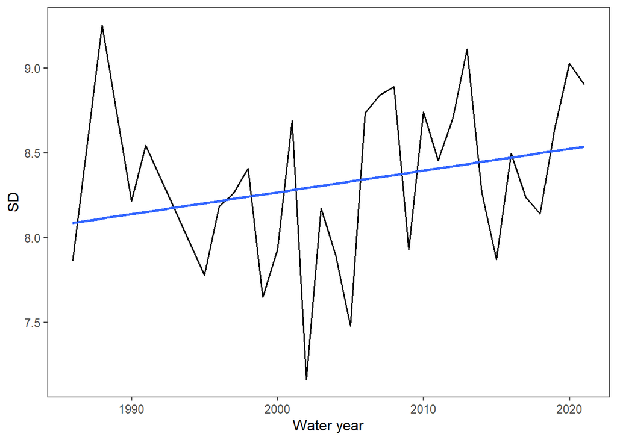

```r
ggplot(standard_dev_all_408_ad, aes(x = waterYear, y = sd_2))+
  geom_line(size= 0.7) +
  theme_few() +
  geom_smooth(method = "lm", se=FALSE) +
  ylab('SD') +
  xlab('Water year')
```

#### MK & SS 408 (corrected)

```r
sd_mk_408_ad <- mk.test(standard_dev_all_408_ad$sd_2)
print(sd_mk_408_ad)
```

```
##
##  Mann-Kendall trend test
##
## data:  standard_dev_all_408_ad$sd_2
## z = 1.6656, n = 31, p-value = 0.09578
## alternative hypothesis: true S is not equal to 0
## sample estimates:
##            S         varS          tau
##   99.0000000 3461.6666667    0.2129032
```

```r
sd_sens_408_ad <- sens.slope(standard_dev_all_408_ad$sd_2)
print(sd_sens_408_ad)
```

```
##
##  Sen's slope
##
## data:  standard_dev_all_408_ad$sd_2
## z = 1.6656, n = 31, p-value = 0.09578
## alternative hypothesis: true z is not equal to 0
## 95 percent confidence interval:
##  -0.002966699  0.039974700
## sample estimates:
## Sen's slope
##  0.01765345
```

# Notes from SF 30/8

Write up the methodology as it stands, discuss some of the results as they are.

Look at when missing days occur and determine if interpolation is possible.

Look at Repass 2005, SF 2006, and Moran et al 2022 draft for interpolation ideas for years with less than 20% missing observations.

Plot the pre-sensor change of Rabbit Ears and Columbine against the post-sensor change.

Insert Theil Sen’s slope against linear regression.

Check missing days/years for the Towers site.

Correlate Rabbit Ears and Columbine. See what the R^2 is.

Look more into Oiler.

# Methodology